# Marked_up_C2W4_Assignment

## Multi-class Classification Sign Language Images

This is a project I did for an online course to become a certified TensorFlow developer. I built a CNN for categorical variables with an available data set images of hands signing letters in ASL.

Let's get started!

```python
import csv
import string
import numpy as np
import tensorflow as tf
import matplotlib.pyplot as plt
from tensorflow.keras.preprocessing.image import ImageDataGenerator, array_to_img
```

Download the training and test sets (the test set will actually be used as a validation set):

```python
!pip install gdown==4.6.0
```

```python
# sign_mnist_train.csv
!gdown --id 1z0DkA9BytlLxO1C0BAWzknLyQmZAp0HR
# sign_mnist_test.csv
!gdown --id 1z1BIj4qmri59GWBG4ivMNFtpZ4AXIbzg
```

Define some globals with the path to both files

```python
# grader-required-cell

TRAINING_FILE = './sign_mnist_train.csv'
VALIDATION_FILE = './sign_mnist_test.csv'
```

The data set does not have the actual images provided, instead the data is serialized as `csv` files.

Let's Take a look at how the data looks like within the `csv` file:

```python
with open(TRAINING_FILE) as training_file:
  line = training_file.readline()
  print(f"First line (header) looks like this:\n{line}")
  line = training_file.readline()
  print(f"Each subsequent line (data points) look like this:\n{line}")
```

```
First line (header) looks like this:
label,pixel1,pixel2,pixel3,pixel4,pixel5,pixel6,pixel7,pixel8,pixel9,pixel10,pixel11,pixel12,pixel13,pixel14,pixel15,pixel16,pixel17,pixel18,pixel19,pixel20,pixel21,pixel22,pixel23,pixel24,pixel25,pixel26,pixel27,pixel28,pixel29,pixel30,pixel31,pixel32,pixel33,pixel34,pixel35,pixel36,pixel37,pixel38…

Each subsequent line (data points) look like this:
3,107,118,127,134,139,143,146,150,153,156,158,160,163,165,159,166,168,170,170,171,171,171,172,171,171,170,170,169,111,121,129,135,141,144,148,151,154,157,160,163,164,170,119,152,171,171,170,171,172,172,172,172,172,171,171,170,113,123,131,137,142,145,150,152,155,158,161,163,164,172,105,142,170,171,17…
```

Each file includes a header (the first line) and each subsequent data point is represented as a line that contains 785 values.

The first value is the label (the numeric representation of each letter) and the other 784 values are the value of each pixel of the image. The original images have a resolution of 28x28, which sums up to 784 pixels.

## Parsing the dataset

This function will read a file passed as input and return 2 numpy arrays, one containing the labels and one containing the 28x28 representation of each image within the file. These numpy arrays will have type `float64`.

A couple of things to keep in mind:

- The first line contains the column headers, so it is ignored.
- Each successive line contains 785 comma-separated values between 0 and 255
  - The first value is the label
  - The rest are the pixel values for that picture and need to be rescaled

```python
def parse_data_from_input(filename):
  #Parses the images and labels from a CSV file

  #Args:
    #filename (string): path to the CSV file

  #Returns:
    #images, labels: tuple of numpy arrays containing the images and labels
  with open(filename, "r") as file:
    #csv.reader, passes in the appropriate delimiter
    # csv.reader can be iterated and returns one line in each iteration
    csv_reader = csv.reader(file)  # None makes skip headers
    next(csv_reader, None)  # skip the headers
    images = []
    labels = []
    for row in csv_reader:
        if (len(np.array(row[1:]))) == 784:
          #there was a few errors in the data where a row did not have correct values for a 28x28 images
          images.append(np.array(row[1:]).reshape(28, 28))
          #pixels are reshaped to 28x28 and appended to a list
          labels.append(row[0])
          #append the label for each row

    images = np.array(images).astype(np.float64)
    labels = np.array(labels).astype(np.float64)
    #convert lists to np arrays
    return images, labels
```

```python
# Test function
training_images, training_labels = parse_data_from_input(TRAINING_FILE)
validation_images, validation_labels = parse_data_from_input(VALIDATION_FILE)

print(f"Training images has shape: {training_images.shape} and dtype: {training_images.dtype}")
print(f"Training labels has shape: {training_labels.shape} and dtype: {training_labels.dtype}")
print(f"Validation images has shape: {validation_images.shape} and dtype: {validation_images.dtype}")
print(f"Validation labels has shape: {validation_labels.shape} and dtype: {validation_labels.dtype}")
```

```
Training images has shape: (27455, 28, 28) and dtype: float64
Training labels has shape: (27455,) and dtype: float64
Validation images has shape: (7172, 28, 28) and dtype: float64
Validation labels has shape: (7172,) and dtype: float64
```

## Visualizing the numpy arrays

Now that the initial csv data is in a format that is compatible with computer vision tasks. Lets actually see how the images of the dataset look:

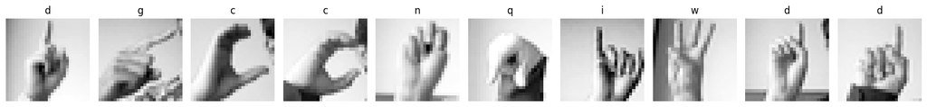

```python
# Plot a sample of 10 images from the training set
def plot_categories(training_images, training_labels):
  fig, axes = plt.subplots(1, 10, figsize=(16, 15))
  axes = axes.flatten()
  letters = list(string.ascii_lowercase)

  for k in range(10):
    img = training_images[k]
    img = np.expand_dims(img, axis=-1)
    img = array_to_img(img)
    ax = axes[k]
    ax.imshow(img, cmap="Greys_r")
    ax.set_title(f"{letters[int(training_labels[k])]}")
    ax.set_axis_off()

  plt.tight_layout()
  plt.show()

plot_categories(training_images, training_labels)
```

## Creating the generators for the CNN

Now that the data can be easily fed to Keras' `ImageDataGenerator`, it is time to code the generators that will yield batches of images, both for training and validation. Some important notes:

- Add "color" dimension to the numpy arrays that encode the images. These are black and white images, so this new dimension should have a size of 1.

```python
def train_val_generators(training_images, training_labels, validation_images, validation_labels):
  #Creates the training and validation data generators

  #Args:
    #training_images (array): parsed images from the train CSV file
    #training_labels (array): parsed labels from the train CSV file
    #validation_images (array): parsed images from the test CSV file
    #validation_labels (array): parsed labels from the test CSV file

  #Returns:
    #train_generator, validation_generator - tuple containing the generators

 #have to add another dimension to the data
  training_images =  np.expand_dims(training_images, axis = 3)
  validation_images =  np.expand_dims(validation_images, axis = 3)

  # Instantiate the ImageDataGenerator class
  #augment training images
  train_datagen = ImageDataGenerator(
      rescale = 1./255,
	    rotation_range=40,
      width_shift_range=0.2,
      height_shift_range=0.2,
      shear_range=0.2,
      zoom_range=0.2,
      horizontal_flip=True,
      #a potential imporvment could be set this to false, I am not sure if ASL signs are symetrical is flipped
      fill_mode='nearest')


  # Pass in the appropriate arguments to the flow method
  train_generator = train_datagen.flow(x=training_images,
                                       y= training_labels,
                                       batch_size=32)


  # Instantiate the ImageDataGenerator class
  validation_datagen = ImageDataGenerator(rescale = 1./255)

  # Pass in the appropriate arguments to the flow method
  validation_generator = validation_datagen.flow(x=validation_images,
                                                 y=validation_labels,
                                                 batch_size=32)

  return train_generator, validation_generator
```

```python
# Test generators
train_generator, validation_generator = train_val_generators(training_images, training_labels, validation_images, validation_labels)

print(f"Images of training generator have shape: {train_generator.x.shape}")
print(f"Labels of training generator have shape: {train_generator.y.shape}")
print(f"Images of validation generator have shape: {validation_generator.x.shape}")
print(f"Labels of validation generator have shape: {validation_generator.y.shape}")
```

```
Images of training generator have shape: (27455, 28, 28, 1)
Labels of training generator have shape: (27455,)
Images of validation generator have shape: (7172, 28, 28, 1)
Labels of validation generator have shape: (7172,)
```

## Coding the CNN

```python
len(np.unique(validation_labels))
```

```
24
```

```python
# grader-required-cell

def create_model():
  # Define the model
  # Use no more than 2 Conv2D and 2 MaxPooling2D
  model = tf.keras.models.Sequential([
    # Note the input shape is the desired size of the image 150x150 with 3 bytes color
    # This is the first convolution
    tf.keras.layers.Conv2D(128, (3,3), activation='relu', input_shape=(28, 28, 1)),
    tf.keras.layers.MaxPooling2D(2, 2),
    # The second convolution
    tf.keras.layers.Conv2D(64, (3,3), activation='relu'),
    tf.keras.layers.MaxPooling2D(2,2),
    # Flatten the results to feed into a DNN
    tf.keras.layers.Flatten(),
    #tf.keras.layers.Dropout(0.2),
    #the previous model attemps did not show signs of overfitting
    #with goal to achieve within 15 epochs I will remove dropout until a model shows overfitting signs
    # 512 neuron hidden layer
    tf.keras.layers.Dense(512, activation='relu'),
    tf.keras.layers.Dense(25, activation='softmax')])


  model.compile(loss = 'sparse_categorical_crossentropy', optimizer= 'rmsprop',
                metrics=['accuracy'])

  return model
```

```python
#save model
model = create_model()



#train model
history = model.fit(train_generator,
                    epochs=15,
                    validation_data=validation_generator)
```

Now take a look at your training history:

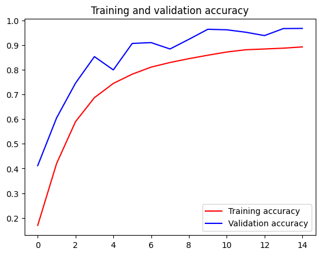

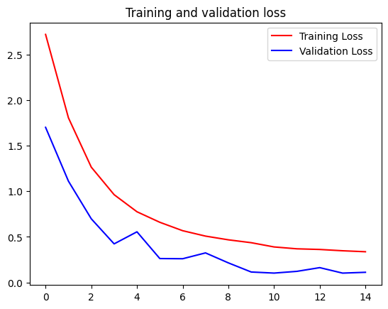

```python
# Plot the chart for accuracy and loss on both training and validation
acc = history.history['accuracy']
val_acc = history.history['val_accuracy']
loss = history.history['loss']
val_loss = history.history['val_loss']

epochs = range(len(acc))

plt.plot(epochs, acc, 'r', label='Training accuracy')
plt.plot(epochs, val_acc, 'b', label='Validation accuracy')
plt.title('Training and validation accuracy')
plt.legend()
plt.figure()

plt.plot(epochs, loss, 'r', label='Training Loss')
plt.plot(epochs, val_loss, 'b', label='Validation Loss')
plt.title('Training and validation loss')
plt.legend()

plt.show()
```

The model performed very well! The goal for our model was to get above 95% accuracy on our validation set using only 2 CNN within 15 epochs. What is more exciting is there is still more potential! Within the 15 epochs there are not yet signs of overfitting. This suggests the more epochs theoretically should improve both training and validation accuracy. Additionally, I did not use layer drop. This is a common solution for overfitting. Both of these suggest the model could be trained with more epochs and improve even further! However, since I hit the target goal I will stop here because I am eager to keep doing more projects.